# La France dans la révolution industrielle: les transformations économiques et sociales de la France du Second empire

Auteur·rice

Skarbimir Prokopek

La période du Second empire est décisive d’un point de vue économique: c’est durant ces deux décennies que la France entre dans la **modernité** définie par la **révolution industrielle**. Dans une perspective plus large, la révolution industrielle est en marche depuis plus d’un demi-siècle lorsque Louis-Napoléon Bonaparte accède au pouvoir. Dès le xviii<sup>e</sup> siècle, la **productivité** de l’industrie (ou proto-industrie) augmente considérablement, mais reste fondée sur la force humaine, animale, et l’utilisation limitée de la force hydraulique: des **manufactures** plus larges sont organisées et permettent l’augmentation de la production et formation des fortunes. On parle parfois de **révolution industrieuse** pour désigner cette phase. Cependant, le processus accélère considérablement, pour devenir réellement explosif en Angleterre, grâce à l’intervention de la force mécanique permise par la **machine à vapeur**: on peut parler, comme le fait Jean-Baptiste Fressoz que les spécialistes HGSSP connaissent, de la civilisation **thermo-industrielle**. L’Angleterre conserve une avance significative; elle est suivie par l’Allemagne, riche en charbon. En France, l’industrialisation est relativement tardive: le pays reste majoritairement agricole, la population française reste moins nombreuse, assez rurale et peu concentrée.  
Cependant, la France n’est pas complètement en dehors du mouvement. Les premières transformations qui pointent vers l’industrialisation capitaliste datent de l’époque napoléonienne: c’est alors que la législation sur les nuisances est réorganisée pour favoriser avant tout l’intérêt des producteurs.  
À l’arrivée de LNB au pouvoir, l’industrie en France est surtout textile et légère; elle est aussi concentrée à Paris et dans quelques autres villes majeures, comme Lyon (le **canuts**).

## 1 *Sa Majesté l’Argent?* La prospérité et la révolutiuon bancaire

Avant de considérer l’industrie elle-même, il faut s’intéresser à l’argent. Le Second empire est soutenu par une importante fraction de conservateurs venus de l’**orléanisme**, détenteurs des fortunes financières et commerciales.  
D’un point de vue social et même culturel, la croissance de grandes fortunes financières, souvent dénoncées d’un point de vue moral par les écrivains du temps, est une marque de fabrique du Second empire. D’une part, la richesse des capitalistes du Second empire, souvent financiers, à l’image des **Rotschild** ou des frères **Pereire**, ne s’appuie plus sur un bagage de tradition des anciennes fortunes foncières, ni de manières sociales des *hommes considérables* du début du siècle. D’autre part, le pouvoir de l’argent apparaît absolu et illimité, d’autant plus frappant que les fortunes sont plus grandes que jamais. Si la représentation donnée par les écrivains comme Émile Zola (*L’Argent*, écrit en 1890, mais aussi *La Curée*, un de ses premiers roamns), **Jules Vallès** qui écrit un autre ouvrage intitulé *L’Argent*, sans oublier *La Fortune des Gaspard* de la **comtesse de Ségur** (l’expression *Sa Majesté l’Argent* est empruntée au titre d’un feuilleton de Xavier de Montépin), est souvent traditionnelle et moralisatrice, d’un point de vue économique, le second empire voit une forte **concentration des capitaux**. Les entreprises dans les secteurs de pointe atteignent des tailles jusque là inconnues et dominent ces secteurs dans une logique de mono- ou oligopole.  
Cette concentration de richesse permet aux détenteurs de grandes fortunes d’exercer une grande influence: les Pereire comme les **Schneider** sont proches du pouvoir impérial auquel ils n’hésitent pas à demander des services, des avantages, et bien sûr la protection contre toute contestation sociale. Les capitalistes occupent directement des postes politiques et investissent dans les journaux qui sont un outil d’influence, mais aussi un investissement très lucratif.

### 1.1 La banque

Au fondement de ce nouveau système financier se trouve la **banque**. Le capital de la **Banque de France** double et les billets sont de plus en plus utilisés. Le réseau des **succursales** se densifie; de nouvelles formes de crédit sont proposées en plus de l’activité traditionnelle de l’**escompte**. Les banques traditionnelles restent relativement prudentes, cependant de nouveaux établissements arrivent et bouleversent l’activité bancaire. Le **Crédit mobilier** des frères **Pereire** est une banque d’investissement, construite comme une **société par actions.** qui finance des entreprises industrielles et ferroviaires. Les Pereire cherchent à créer des activités et à les contrôler au sein de véritables holdings. Contrairement aux banques traditionnelles qui travaillent avec leurs capitaux propres (cas des **Rotschild**), la banque des Pereire est plus dispendieuse et doit en permanence chercher des capitaux dans l’émission des titres, ce qui rend leur entreprise plus fragile.

[figure not shown]

Les frères Pereire

Dans le sillage des Pereire, plusieurs autres banques mixtes – alliant l’activité d’investissement et de **dépôt**, sont créées. En proposant des formules de dépôt à vue, des comptes courants et différents types d’épargne, ces banques peuvent diriger l’argent des petits épargnants vers le commerce et l’industrie.

> [Les frères Pereire] ont regroupé dans leurs mains l’épargne des bourgeois et des masses populaires, pour en diriger les flots tumultueux vers l’industrie et le commerce. Les chemins de fer et les organisations économiques modernes sont des entreprises si vastes qu’il est impossible de les construire et de les faire marcher à l’aide des capitaux d’un individu. Il fallait les capitaux de la masse, […]. Les Pereire ont entrepris cette tâche, et ils peuvent se vanter d’avoir accompli un miracle: […] ils ont pu trouver les capitaux dont avait besoin à ses débuts la grande industrie enplein essor.

> Paul Lafargue, *Die Neue Zeit*, 1892

Toutes les grandes banques françaises actuelles, à l’exception du Crédit Agricole, ont été créées durant le Second empire: le Crédit industriel et commercial (CIC) en 1859, le Crédit lyonnais en 1863, la Société Générale en 1864, la Banque des Pays-Bas (1864) et la Banque de Paris (1869), qui formeront ensuite Paribas.

### 1.2 La Bourse

La bourse est au cœur des carrières flamboyantes typiques du Second empire, mais aussi au centre des critiques morales dont les romans réalistes et/ou naturalistes sont pleins. Paris devient une placez financière international; ses activités augmentent rapidement. Le **nombre des valeurs cotées** françaises fait plus que doubler, celui des valeurs étrangères quadruple, le nombre total triple. Des bourses régionales sont crées durant la période.  
Le coup d’État provoque une hausse des cours et ouvre une période d’euphorie chez les **spéculateurs**. Par la suite, la vie politique (les guerres étrangères, les traités internationaux etc) se répercutent à la bourse, faisant varier les cours. Or, les variations des prix est bien ce qui permet de réaliser des profits à ceux qui *jouent à la bourse*.  
La pratique se répand: tous les journaux ont désormais une rubrique boursière, que les intéressés suivent avec application, voire émotion. Les écrivains ne cessent de dénoncer la Bourse et son influence sociale. Les profits sont rapides et déconnectés de toute forme de travail; qui plus est, les spéculateurs ou *boursicoteurs* bénéficient des fluctuations du marché ou troubles politiques, leurs gains apparaissent donc d’autant plus illégitimes.

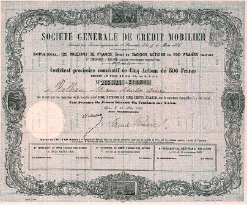

La spéculation boursière et immobilière sont liés: les entrepreneurs de l’immobilier, tels que les Pereire (ou leur équivalent littéraire, Saccard de *La Curée* de Zola), lancent dans le jeu de la Bourse l’argent gagné en jouant sur le prix des immeubles et sur les indemnités d’expropriation versées aux propriétaires des immeubles destinés à la destruction.

### 1.3 Financer les entreprises

Si l’argent est dénoncé comme puissance démoralisante et destructrice de la société, de la morale, voire du tissu urbain, l’argent est indispensable pour le développement de l’économie. Le problème central (décrit par le passade de Paul Lafargue cité plus haut), est que l’activité économique nécessite des quantités d’argent complètement inaccessibles à un individu, même fortuné, et même à une association d’individus fortunés (**société en nom collectif**).  
Pour les sociétés déjà existantes, l’expansion exige aussi des investissements. Une partie considérable des bénéfices est réinvestie, mais même cela est souvent insuffisant. Il faut donc que les entreprises croissent avec «l’argent des autres», selon le mot d’Alexandre Dumas. Une première manière de toucher l’«argent des autres» est d’émettre des valeurs mobilières, qui sont d’abord des **obligations**.  
Les entreprises nouvelles prennent de plus en plus la forme des **sociétés anonymes** (SA) ou des sociétés en **commandite par actions** (SCA), formez qui permet de faire appel à l’épargne de très nombreux actionnaires. Cette forme, encore minoritaire mais très appropriée pour des sociétés de taille importante, est favorisée par l’État. En 1863, une loi supprime l’obligation d’une autorisation préalable à la création d’une société anonyme, les libérant partiellement de la tutelle politique. En 1867, une autre loi d’inspiration libérale supprime la limitation du capital et stipule:

> À l’avenir, les sociétés anonymes pourront se constituer sans autorisation du Gouvernement.

Cette loi, en vigueur jusqu’en 1966 (soit presque exactement un siècle) instaure de fait un pouvoir des conseils d’administration.

## 2 Le train et l’usine: la révolution industrielle

La **révolution industrielle** est déjà en marche lorsque le Second empire s’installe au pouvoir; ses effets se sentent déjà sentir mais la France est pour l’essentiel restée à l’écart de ce processus.  
Dès le xviii<sup>e</sup> siècle, la productivité augmente, des unités de production plus grandes sont constituées, même si cela repose pour l’instant sur la force des muscles humains, animaux et la force hydraulique. Mais l’exploitation de la force hydraulique permet déjà des progrès techniques: on parle de la **révolution industrieuse**. Le basculement dans une autre époque intervient avec l’intervention d’une nouvelle forme d’énergie. La **machine à vapeur** de **James Watt (1775)** (certes, aboutissement de plusieurs développements esquissé par différents ingénieurs, et sujette à des améliorations ultérieures, si bien que la date est au fond symbolique), posée sur les rails par Richard Trevithick en 1803, permet d’augmenter rapidement la puissance disponible et de s’affranchir des contraintes naturelles et sociales de la machine hydraulique. En **1825, la première ligne de chemin de fer** Stockton-Darlington est inaugurée.

[figure not shown]

Le train de Saint-Germain – viadus de Meudon

L’Angleterre entre la première dans la révolution industrielle, grâce à sa position économique déjà dominante (le processus des **clôtures**, subordonnant l’agriculture anglaise à la production exportatrice de laine, est déjà bien avancé), mais aussi grâce à ses réserves importantes et accessibles de charbon. L’Allemagne suit, pour la même raison. En France, la situation est moins favorable: la population est massivement rurale et plutôt dispersée, les réserves de charbon sont plus réduites, le tissu économique est plus fragmenté. Cependant, dès le Premier empire, la loi évolue dans un sens favorable aux entreprises productives.

### 2.1 Un volontarisme d’État

Le Second empire cherche consciemment à stimuler le développement économique. LNB lui-même, comme plusieurs personnes de son entourage et certains entrepreneurs, comme les Pereire, sont influencés par le **saint-simonisme** qui prône la modernisation technique et un interventionnisme d’État. Cela distingue LNB des dirigeants précédents: il manque certes d’éducation classique typique des *hommes considérables* de la Monarchie de juillet, mais s’intéresse beaucoup plus qu’eux aux questions techniques et sociales, qu’il comprend mieux. Il rompt avec la prudence d’un Louis-Philippe qui estimait, comme toute la bourgeoisie orléaniste, que l’État devrait laisser jouer les forces économiques. Il s’agit d’un objectif assumé et politique: l’empire se propose *l’extinction du paupérisme* comme objectif, ce qui nécessite des moyens. L’enrichissement général et l’amélioration du sort des plus pauvres doivent aussi faire accepter le régime. Dans son discours de Bordeaux, dès 1852, puis dans une lettre au ministre Fould en 1860, déclare:

> qu’il faut multiplier les moyens d’échange pour rendre le commerce florissant; que sans commerce l’industrie est stationnaire et conserve des prix élevés qui s’opposent aux progrès de la consommation; que sasn une industrie prospère qui développe les capitaux, l’agriculture elle-même demeure dans l’enfance. Tout s’enchaîne donc dans le développement progressif de la prospérité publique… En ce qui touche l’agriculture, il faut la faire participer aux bienfaits des institutions de crédit…; affecter tous les ans une somme considérable aux grands travaux de dessèchement, d’irrigation et de défrichement… Pour encourager la production industrielle , il faut prêter (à l’industrie), exceptionnellement et à un taux modéré, les capitaux qui l’aideront à perfectionner son matériel. Un des plus grands services à rendre au pays est de faciliter les transports des matières de première nécessité pour l’agriculture et l’industrie; à cet effet le ministre des Travaux publics fera exécuter le plus promptement possible les voies de communication, canaux, routes et chemins de fer qui auront surtout pour but d’amener la houille et les engrais sur les lieux où les besoins de la production les réclament.

Ce volontarisme nécessite des dépenses importantes. Le Second empire est par conséquent dépensier par choix, et comme il ne faut pas mécontenter les milieux économiques en augmentant les impôts (rappelez vous du rejet des «45 centimes» chez les paysans), on recours massivement à l’emprunt.  
L’opposition politique a eu tendance a exagérer cette facilité des dépenses qui inquiète la finance traditionnelle. En réalité, les investissements directs de l’État sont relativement limités; l’essentiel des travaux est accomplis par des compagnies **concessionnaires** qui gagnent beaucoup d’argent dans le processus.  
Enfin, l’État fort, non démocratique et donc affranchi du contrôle d’un parlement (avant les réformes de la fin des années 1860 qui n’ont pas le temps de changer les choses) rassure les acteurs économiques; arbitre en leur faveur dans les conflits sociaux et/ou territoriaux, soutient les grandes entreprises en leur laissant écraser les petites.

La transformation de Paris est le meilleur exemple du volontarisme parfois brutal. Napoléon III tient personnellement à changer l’apparence de la capitale; il confie la réalisation de cette tâche imposante à un homme à poigne, type même de *grand commis de l’État* que l’on retrouvera à l’époque gaullienne, le préfet Haussmann.

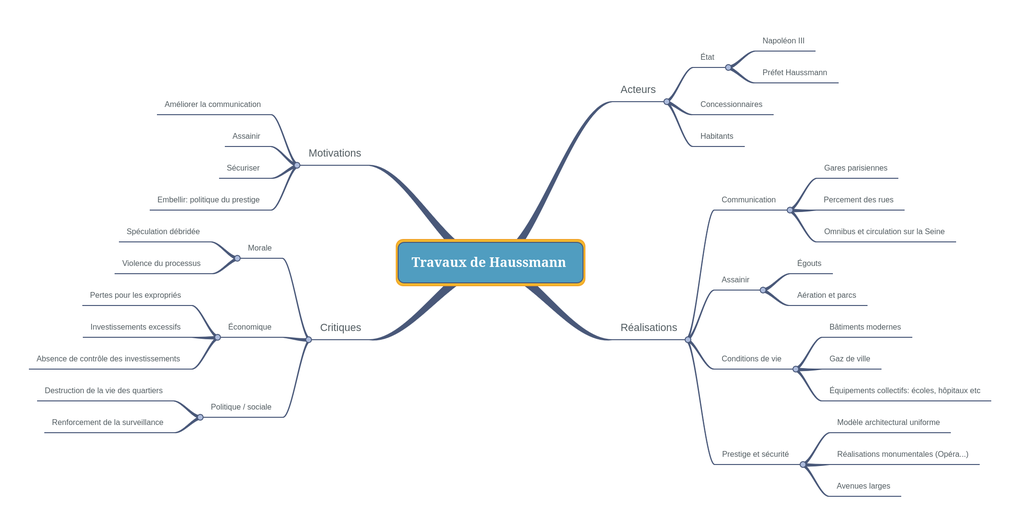

LEst travaux d’Haussmann – la carte mentale

Les objectifs sont multiples. Paris a absorbé une immigration (majoritairement intérieure!) massive. En 1866, seulement un tiers des habitants de Paris y sont nés, 61% viennent de province, 6% viennent de l’étranger. Les nouveaux-venus provinciaux viennent pour la plupart des campagnes proches du Nord et de l’Est – on n’en est pas encore à l’arrivée des Bretons et des *Bougnats* (Auvergnats) que connaîtra la fin du siècle. La ville étouffe dans les limites devenues trop étroites de l’enceinte des Fermiers généraux. Ainsi, comme prélude aux grands travaux, une «proche banlieue» des communes limitrophes est annexée à Paris, qui s’adosse à la ceinture des fortifications des années 1840 et trouve ses frontières actuelles. Le plan des arrondissements est redessiné, les 20 arrondissements actuels remplacent les 12 anciens. En conséquence, la banlieue connaît une industrialisation rapide, comme dans la plaine de Saint-Denis ou à Vanves.  
Il faut donc agrandir, aérer et assainir la ville où les conditions sanitaires sont désastreuses dans les vieux quartiers denses aux ruelles étroites et insalubres: les épidémies de choléra des années 1830 le prouvent (pour une représentation littéraire du choléra à cette époque, certes dans une autre région et avec quelque exagération, vous pouvez ouvrir *Le Hussard sur le toit* de Jean Giono… mais les images sont dures). Les **égouts** conçus par **Eugène Belgrand**, mais inachevés avant la chute de l’empire (les propriétaires résistent à l’obligation du tout-à-l’égout, qui leur coûte de l’argent) y remédient tandis que les parcs et squares, dessinés par **Adolphe Alphand** cherchent à améliorer l’air et apaiser les esprits. La ville capitaliste a besoin de voies de circulation aisée: les magasins (encore Zola: *Au Bonheur des Dames* met en scène un grand magasin fictif, inspiré comme les vrais du **Bon Marché** d’**Aristide Boucicaut**; on y trouve toute la panoplie des techniques *marketing* encore parfaitement en vigueur), les banques, surtout les **gares-terminus** qui désormais déversent les voyageurs en quantités inédites. Il faut donc des artères larges et des transports urbains.  
L’empereur et son préfet poursuivent un objectif de prestige, la ville doit rivaliser avec Londres, il lui faut donc une apparence imposante et des édifices de prestige – ainsi, les **Halles**, œuvre de **Victor Baltard** (mises en scène dans *Le Ventre de Paris* de l’inévitable Zola) sont un exemple de modernité architecturale caractéristique de l’esprit d’ingénieur de l’époque, tandis que l**Opéra-Garnier** illustre le goût bourgeois conservateur et éclectique.  
Il y enfin un objectif sécuritaire: les travaux permettent de raser d’anciens quartiers populaires où les activités subversives, ou les *sociétés secrètes* que l’on soupçonne facilement à l’époque, pourraient se cacher; les anciennes rues étroites et sinueuses se prêtaient à la construction des barricades. L’actuelle place de la République est un bon exemple: l’ancien quartier du *Boulevard du crime* (appelé ainsi à cause des théâtres où des crimes étaient représentés sur scène, non de vrais crimes) a été remplacé par l’actuelle place encadrée par un grand magasin et une caserne, parfaite expression de l’ordre étatique, bourgeois et capitaliste.

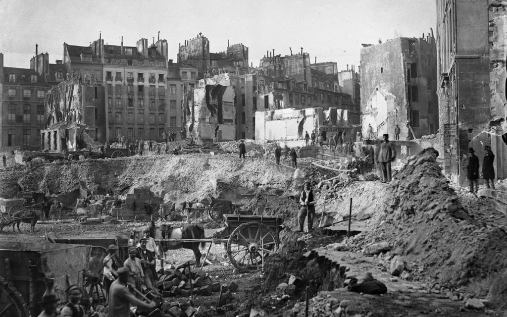

Les travaux d’Haussmann en cours

Les travaux, dont la principale manifestation est le percement des grandes artères (la rue Rambuteau est la première, suivie par les boulevards qui deviennent le modèle pour les travaux ultérieurs), sont menés de manière très énergique, mais majoritairement à travers les compagnies concessionnaires privées. Les résultats sont reconnus, de nos jours et même sous la III<sup>e</sup> République, pourtant globalement hostile au souvenir du Second empire. Pourtant, dans l’immédiat, c’est un échec politique. Les regrets des propriétaires expropriés et des habitants dérangés dans leurs habitudes, souvent forcés de se déplacer vers les banlieues plus homogènes socialement, l’emportent.

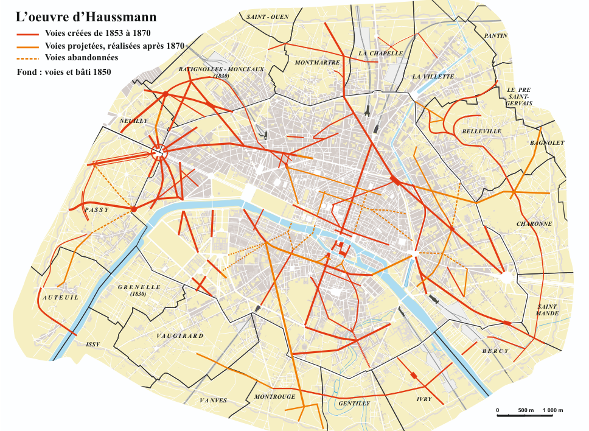

Carte des réalisations d’Haussmann

### 2.2 La révolution des transports

La révolution ferroviaire, et dans une moindre mesure maritime, est un aspect central du Second empire. La construction des chemins de fer est balbutiante à l’avènement de ce régime. Le chemin de fer de Paris à Saint-Germain-en-Laye, déjà construit largement par les Pereire, est le premier en France; il est inauguré en 1837, soit plus de 10 ans après la première ligne anglaise. En 1851, le réseau ne compte qu’un peu moins de 3250 kilomètres, il y en a presque 16 500 en 1869.  
Les principales lignes sont toutes construites dans la première décennie de l’existence du régime. À partir de 1863, la conjoncture économique se fait plus difficile tandis que les lignes qui restent à construire sont moins rentables. Mais le public et les élus locaux continuent à réclamer le train, l’État doit donc intervenir davantage.  
Le réseau est partagé entre une multitude de compagnies qui se livrent des «guerres de réseaux» pour le partage du marché. La situation se stabilise à la fin des années 1850 et ne sera véritablement remise en cause qu’au xx<sup>e</sup> siècle.

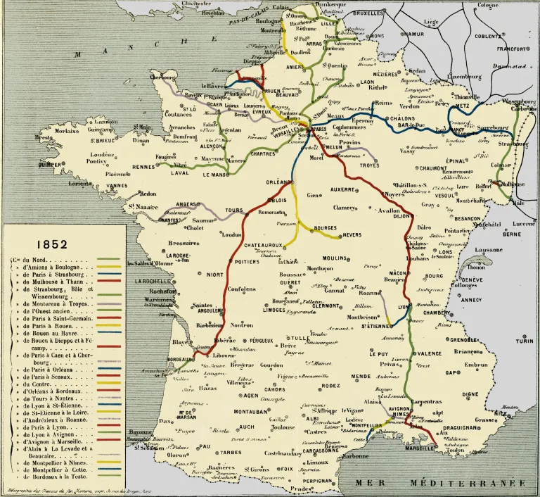

Le réseau ferroviaire en 1852

Le développement du train a des effets massifs. Forcément, le temps des trajets est rapidement réduit, comme le coût du transport des marchandises. L’espace n’est pas seulement rétréci, il est aussi unifié: la révolution des transports apporte un **désenclavement**. L’économie traditionnelle était cloisonnée, de plus en plus elle forme un marché national.  
Le désenclavement est mental autant que matériel: en plus des hommes et des marchandises, voyagent les idées sous forme des journaux (qu’il est facile d’imprimer en grandes quantités grâce à d’autres avancées techniques dans l’imprimerie), voire des livres diffusés massivement par Louis Hachette.

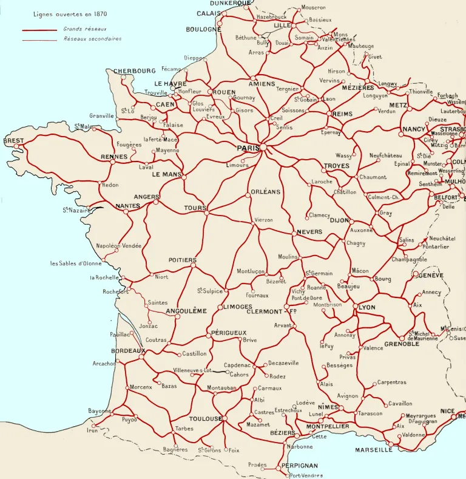

Le réseau ferroviaire en 1870

Enfin, la construction du réseau ferroviaire alimente l’industrie. Les rails (qui s’usent très vite et doivent être constamment remplacés), les locomotives ou encore les charpentes métalliques des gares doivent être commandés aux entreprises sidérurgiques qui se développent et qui innovent pour répondre à cette demande.

### 2.3 L’essor de la grande industrie

Dans l’absolu, une industrie traditionnelle, faite plus d’ateliers que d’usines continue à dominer. Autre trait constant, l’industrie légère (surtout textile), l’emporte sur l’industrie lourde, et cela ne changera pas avant la Première guerre mondiale. Cependant, l’industrie change massivement et rapidement. La mécanisation et l’équipement en machines et métiers progresse; la machine à vapeur remplace la force hydraulique et donne la forme que nous connaissons à l’usine, avec son architecture familière, faite de vastes bâtiments où un grand nombre ouvriers (ou ouvrières, surtout dans l’industrie textile) et d’équipements encombrants sont réunis et organisés rationnellement. L’usine a besoin d’une ou plusieurs machines à vapeur qui entraînent toutes les machines par l’intermédiaire des arbres de transmission au plafond et des courroies que l’on reconnaît facilement sur les illustrations de l’époque.

[figure not shown]

*Le Creusot vu du nord*, 1847, aquarelle de Pierre Trémaux

La sidérurgie est à la pointe de l’innovation technique et de l’organisation industrielle. La grande métallurgie tend à éliminer les dernières *forges catalanes* globalement inchangées depuis le Moyen Âge (et reposant sur la force hydraulique qui entraîne un marteau mécanique, nommé *martinet*), dont il reste cependant une centaine en 1864, et les hauts fourneaux au bois (dont il reste 210 à la même date, alors que 80% de l’acier est produit au coke). Les usines métallurgiques de Schneider, au Creusot, font office d’usine-type. L’entreprise prospère sur les commandes ferroviaires, plus tard maritimes et militaires, et fournit 10% du million de tonnes de la production sidérurgique française; son concurrent De Wendel fournit 11%.  
À partir de 1861, l’emploi du procédé développé par l’ingénieur anglais **Henry Bessemer** (breveté en 1855) permet de produire de l’acier en plus grande quantité et à un coût très inférieur, et combler en partie le retard de l’industrie française face à l’Angleterre.

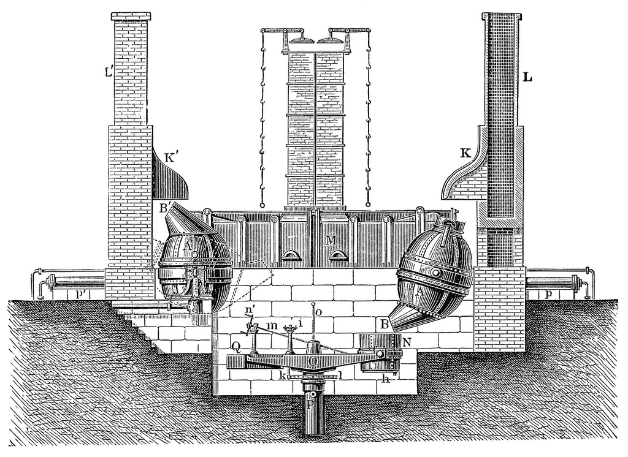

Plan de l’usine Bessemer à Sheffield

La sidérurgie ne peut fonctionner sans l’extraction minière. Les réserves françaises sont inférieures et moins accessibles que celles dont disposent l’Angleterre et l’Allemagne mais l’activité dans le Nord et le Pas-de-Calais se développe: les gisements sont découverts en 1847, concédés entre 1850 et 1855, la région devient le **premier bassin houiller** français en 1863.

De nouvelles branches émergent: l’industrie chimique, organisée par de grandes entreprises comme Saint-Gobain oui Kuhlmann, connaît une croissance rapide et un mouvement de concentration.

## 3 L’enrichissement et l’inégalité: la société sour le Second empire

### 3.1 La «fête impériale» de la bourgeoisie

Le Second empire, surtout sa première partie, marquée par une conjoncture économique favorable, est une période faste de la bourgeoisie. Les enrichissements spectaculaires permettent à certains de rejoindre la bourgeoisie, à d’autres de monter à l’intérieur de cette classe qui n’est absolument pas homogène. Ces nouveaux-riches dont l’opulence repose sur des sources souvent vues comme peu légitimes, contribuent à la réputation sulfureuse de la «fête impériale» et ses plaisirs, dénoncés abondamment par les écrivains déjà plusieurs fois cités (en particulier, *La Curée* d’Émile Zola).

En dépit de ces excès, la bourgeoisie conserve largement une mentalité traditionnelle et reste méfiante des personnages dans le genre de Saccard. S’ils condamnent l’ascension trop rapide et pas assez prudente, ils partagent généralement la préoccupation de l’argent et le rejet de tout ce qui menacerait ses intérêts – l’impôt, les réformes sociales, la guerre et surtout le désordre.

L’argent doit être visible; la bourgeoisie tient à se distinguer du peuple par un mode de vie très voyant. La nécessité de **paraître** se retrouve dans les intérieurs bourgeois, très chargés en sièges capitonnés, teintures, bibelots…, les repas (extrêmement copieux, cf *Le Ventre de Paris*, toujours de Zola), ou encore les loisirs, tels que les promenades ou les sorties théâtrales qui sont toujours autant de moments où se montrer et se comparer à ses pairs.

### 3.2 Les ouvriers: paternalisme, inégalité et luttes

Les ouvriers sont, surtout, de plus en plus nombreux. La croissance industrielle a besoin de bras et les cherche dans les campagnes. Cependant, on n’est pas encore tout à fait dans l’*exode rural*: une partie importante de l’industrie est encore dispersée dans les campagnes, et les ouvriers gardent de très fortes attaches rurales – si presque tout le monde a une famille à la campagne, de très nombreux ouvriers gardent un bout de terre sur lequel ils peuvent se rabattre si les temps deviennent difficiles, voire y retournent de manière saisonnière.

La condition ouvrière est dure: c’est là sa première caractéristique. On a longtemps débattu pour savoir si les ouvriers se sont appauvris *dans l’absolu* durant cette période. Les marxistes l’ont soutenu. Il semblerait que ce ne soit pas le cas *dans l’absolu*, mais c’est le cas *relativement*, ce qui est souvent plus important. Le gouffre qui sépare le niveau de vie des ouvriers des bourgeois s’est creusé, se sont aussi accru les inégalités entre les ouvriers. L’**accroissement des inégalités** est caractéristique de toutes les périodes de **croissance économique**: la croissance produit toujours l’**extrême richesse** et l’**extrême pauvreté**. Si les profits spéculatifs explosent, les salaires progressent très peu (et les prix augmentent, ce qui est en général, sauf notre époque, le signe d’une croissance). Ainsi, dans l’industrie textile, le profit annuel moyen d’un entrepreneur est de 31 900 francs, le salaire moyen de 565 francs. Une telle disparité, jointe à la rigidité des classes qui rend les ascensions quasi impossibles, rend impossible tout sentiment commun: pour l’ouvrier, le bourgeois n’est plus qu’un ennemi, pour le bourgeois, l’ouvrier est un barbare dangereux dont on a peur. Les conditions de travail, non régulées, sont effroyables. La loi du Gouvernement provisoire qui limitait le temps du travail a été abrogée (on est revenus à 12 heures journalières partout dès l’époque de la Constituante). À Lille, ville de grande industrie textile, on travaille 13 ou 15 heures par jour, et les patrions considèrent le temps des repas comme du temps perdu, donc forcent les ouvriers à manger en travaillant. Le salaire journalier est de 2,50 francs, ce qui ne suffit pas à nourrir une famille. Par conséquent, les femmes sont foncées de travailler aussi, pour des salaires encore plus bas (1,50 F au plus). Le travail des enfants, soumis à des journées tout aussi longues et payés encore moins, est massif. L’usine est un environnement violent, bruyant et dangereux: les engrenages et les courroies de transmissions sont exposés et peuvent happer les parties du corps ou des vêtements, les machines sont nettoyées sans être arrêtées pour gagner du temps. Les logements ressemblent à des taudis, des déménagements *à la cloche de bois* ou *à la Saint-Pierre* sont fréquents quand le moindre coup du sort (maladie, accident de travail…) empêche de payer le loyer. Pour rester dans les références littéraires, c’est le monde du *Germinal*, mais aussi celui de *L’Assommoir*.

[figure not shown]

Atelier de filature de Madame Veuve Géhin à Saulxures-sur-Moselotte, Vosges

Quelques patrons, dans un esprit très proche du saint-simonisme napoléonien, pratique une politique **paternaliste**, visant à améliorer les conditions matérielles de l’existence des ouvriers tout en les contrôlant, non seulement par la gratitude qu’ils attendent, mais aussi par des dispositifs beaucoup plus contraignants: c’est la stratégie du métallurgiste **Schneider** au Creusot, qui loge les ouvriers, mais a par la même occasion le pouvoir de refuser le logement aux récalcitrants.

### 3.3 L’âge d’or de la paysannerie

Le monde rural – qui est plus large que la paysannerie au sens strict, les artisans de village, les cafetiers, les fonctionnaires ruraux… sont indirectement liés à la terre – demeure majoritaire en France. Les conditions de vie des paysans demeurent difficiles, même lorsque leur situation s’améliore, puisque dans les campagnes on s’astreint à une vie extrêmement frugale pour pouvoir acheter un gout de terre supplémentaire. Le même comportement retarde la modernisation puisqu’on répète des travaux de force plutôt que d’investir dans le renouvellement de l’outillage. Une représentation visuelle du paysan reste *L’homme à la houe* de Millet (peint en 1860-1862); *L’Angélus* (1858) du même auteur, très largement reproduit et moins douloureux, est, à en croire Pierre-Jakez Hélias (anthropologue qui décrit dans un ouvrage à succès son enfance paysanne en Bretagne au début du xx<sup>e</sup> siècle), la représentation préférée par les paysans eux-mêmes qui se reconnaissent volontiers dans le tableau. Cependant, les progrès sont bien réels. Les revenus des paysans augmentent, tout comme les salaires agricoles. La grande pauvreté dans les campagnes recule. La baisse des naissances et l’émigration vers les villes y contribuent.

[figure not shown]

*L’Angélus*, Jean-François Millet, 1858

Les principaux progrès viennent des grands travaux entrepris par l’empire, et des retombées de la révolution ferroviaire. Dans les Landes, la Brenne et la Sologne ou les Dombes ce sont des travaux de drainage, en Provence on construit au contraire des canaux d’irrigation. Les cultivateurs eux-mêmes poursuivent des défrichements, si bien que la superficie agricole utile (SAU) atteint 26 500 000 ha, soit le maximum jamais atteint dans l’histoire de France. Dans les grandes régions agricoles (Beauce, Picardie) de nouveaux systèmes de rotation des cultures permettent d’abandonner la jachère et lui substituer la prairie artificielle.

L’arrivée du train permet, d’une part, d’apporter des fertilisants nouveaux dans un monde où les engrais artificiels sont encore très rares; d’autre part, le train pousse à abandonner la traditionnelle polyculture et se concentrer sur les cultures commerciales les plus rentables.

## Conclusion

Il est difficile de ne pas envisager la période du Second empire en termes de continuité ou rupture, tradition ou modernité. Incontestablement, les deux se mélangent durant ce temps: comme en politique, la période est ambiguë. Mais les percées de la modernité sont décisives et portent des effets à long terme qui ne seront bien visibles que dans les les décennies suivantes. Si en politique, le trait décisif est probablement l’acculturation démocratique au vote, étonnant effet secondaire de cette période autoritaire, en ce qui concerne la structure sociale et économique, la modernisation du Second empire ne prépare pas la chute du régime, comme Marx l’espérait dans les derniers paragraphes de son *18 Brumaire*, mais annoncent bien les avancées que l’on ne vera que dans la deuxième ou troisième décennie de la Troisième République.